# Tugas Pertemuan 1 MPDW

## Pembagian data latih dan data uji dilakukan dengan perbandingan 80% data latih dan 20% data uji.

### Data training dan testing

```r
training<-data.turis[1:106,2]
testing<-data.turis[107:133,2]
training.ts<-ts(training, frequency = 12, start = 2009)
testing.ts<-ts(testing, frequency = 12, start=2017)
```

### Eksplorasi Data latih dan data uji Eksplorasi data dilakukan pada keseluruhan data, data latih serta data uji menggunakan plot data deret waktu.

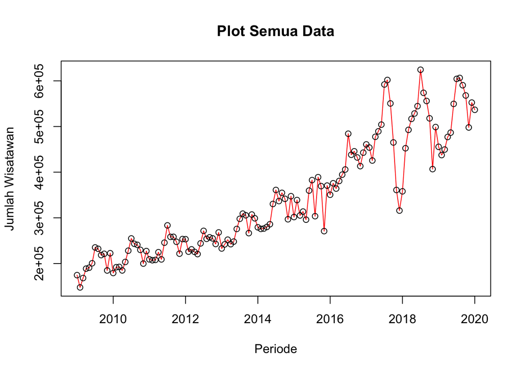

```r
#eksplorasi keseluruhan data
plot(dataturis.ts, col="red",main="Plot Semua Data", xlab="Periode", ylab="Jumlah Wisatawan")
points(dataturis.ts)
```

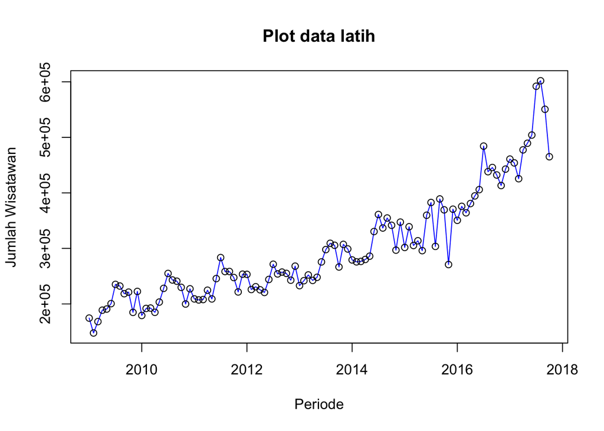

```r
#eksplorasi data latih
plot(training.ts, col="blue",main="Plot data latih", xlab="Periode", ylab="Jumlah Wisatawan")
points(training.ts)
```

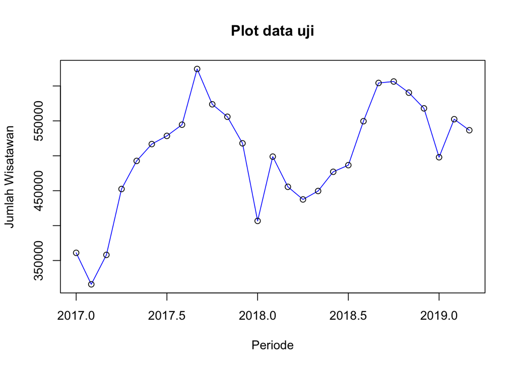

```r
#eksplorasi data uji
plot(testing.ts, col="blue",main="Plot data uji", xlab="Periode", ylab="Jumlah Wisatawan")
points(testing.ts)
```

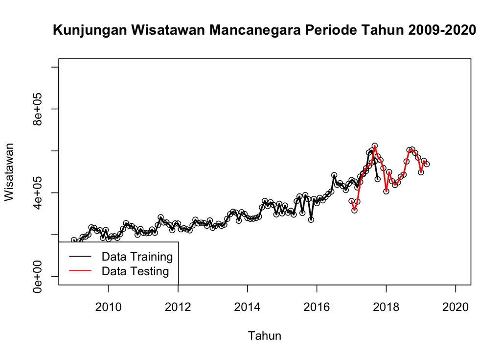

```r
plot(training.ts, main = "Kunjungan Wisatawan Mancanegara Periode Tahun 2009-2020",
     xlab = "Tahun", ylab="Wisatawan", xlim=c(2009,2020), ylim=c(0,1000000), lwd=2)
points(training.ts)
points(testing.ts)
lines(training.ts, col ="black", lwd=2)
lines(testing.ts, col ="red", lwd=2)
legend("bottomleft", c("Data Training", "Data Testing"), lty=1, col=c("black", "red"))
```

Berdasarkan analisis plot deret waktu jumlah kunjungan wisatawan mancanegara pada data training dan testing, dapat disimpulkan bahwa data tersebut tidak bersifat stasioner karena plot data tidak menyebar di sekitar rata-rata serta ragam yang konstan. Jadi data tersebut tidak stasioner dalam rata-rata dan ragam.

## Smoothing

### Double Exponential Smoothing

#### Iterasi Mencari Nilai Alpha Beta Optimum

```r
a = c(0.1, 0.2, 0.3, 0.4, 0.5, 0.6, 0.7, 0.8, 0.9)
b = c(0.1, 0.2, 0.3, 0.4, 0.5, 0.6, 0.7, 0.8, 0.9)
output1 = data.frame()
for (i in a) {
  for (j in b) {
    des1 <- HoltWinters(training.ts, alpha = i, beta=j, gamma=F)
    sse1 <- des1$SSE
    mse1 <- sse1/length(training.ts)
    rmse1 <-sqrt(mse1)
    akurasi1 <- cbind("SSE"=sse1, "MSE"=mse1, "RMSE"=rmse1)
    output1 <- rbind(output1, akurasi1)
  }

}
output_des1 <- cbind("Alpha" = rep(c(0.1,0.2,0.3,0.4,0.5,0.6,0.7,0.8,0.9), each=9), "Beta"=b, output1)
kableExtra::kable(output_des1 ,caption = 'Mencari Parameter Optimum dalam Metode Double Exponential Smoothing',  align = rep('c',7))
```

Mencari Parameter Optimum dalam Metode Double Exponential Smoothing

| Alpha | Beta | SSE | MSE | RMSE |
| --- | --- | --- | --- | --- |
| 0.1 | 0.1 | 524707042746 | 4950066441 | 70356.71 |
| 0.1 | 0.2 | 330028487172 | 3113476294 | 55798.53 |
| 0.1 | 0.3 | 258798113085 | 2441491633 | 49411.45 |
| 0.1 | 0.4 | 226190589301 | 2133873484 | 46193.87 |
| 0.1 | 0.5 | 215823722348 | 2036072852 | 45122.86 |
| 0.1 | 0.6 | 212347969985 | 2003282736 | 44758.05 |
| 0.1 | 0.7 | 211706867819 | 1997234602 | 44690.43 |
| 0.1 | 0.8 | 214575111123 | 2024293501 | 44992.15 |
| 0.1 | 0.9 | 219601327958 | 2071710641 | 45516.05 |
| 0.2 | 0.1 | 212738096523 | 2006963175 | 44799.14 |
| 0.2 | 0.2 | 168866224124 | 1593077586 | 39913.38 |
| 0.2 | 0.3 | 161848782062 | 1526875302 | 39075.25 |
| 0.2 | 0.4 | 165454615800 | 1560892602 | 39508.13 |
| 0.2 | 0.5 | 174035440118 | 1641843775 | 40519.67 |
| 0.2 | 0.6 | 186259921429 | 1757169070 | 41918.60 |
| 0.2 | 0.7 | 202037724778 | 1906016271 | 43657.95 |
| 0.2 | 0.8 | 221100823536 | 2085856826 | 45671.18 |
| 0.2 | 0.9 | 242334551841 | 2286175017 | 47813.96 |
| 0.3 | 0.1 | 154766249051 | 1460058953 | 38210.72 |
| 0.3 | 0.2 | 142210149381 | 1341605183 | 36627.93 |
| 0.3 | 0.3 | 146711882394 | 1384074362 | 37203.15 |
| 0.3 | 0.4 | 156271084647 | 1474255516 | 38396.04 |
| 0.3 | 0.5 | 167794818325 | 1582969984 | 39786.56 |
| 0.3 | 0.6 | 178947817596 | 1688186958 | 41087.55 |
| 0.3 | 0.7 | 187068500200 | 1764797172 | 42009.49 |
| 0.3 | 0.8 | 190005358891 | 1792503386 | 42337.97 |
| 0.3 | 0.9 | 187490997656 | 1768782997 | 42056.90 |
| 0.4 | 0.1 | 133942196716 | 1263605629 | 35547.23 |
| 0.4 | 0.2 | 131408199553 | 1239699996 | 35209.37 |
| 0.4 | 0.3 | 137822477654 | 1300212053 | 36058.45 |

[output cut: 51 more lines]

Hasil optimal untuk parameter double exponential smoothing (DES) berdasarkan metrik evaluasi model adalah alpha = 0.7 dan beta = 0.1, sehingga kita akan menggunakan parameter ini untuk melanjutkan metode pemulusan DES.

```r
df_des1 <- HoltWinters(training.ts, alpha = 0.7, beta=0.1, gamma=F)
head(df_des1$fitted)
```

```
##              xhat    level      trend
## Mar 2009 120867.0 147704.0 -26837.000
## Apr 2009 130480.3 154003.6 -23523.340
## May 2009 151844.6 171287.3 -19442.638
## Jun 2009 162399.9 179115.5 -16715.553
## Jul 2009 175072.3 189116.2 -14043.929
## Aug 2009 207325.1 217160.3  -9835.126
```

```r
datades1 <- data.frame(training.ts, c(NA, NA, df_des1$fitted[,1]))
colnames(datades1) = c("y","yhat")
head(datades1)
```

```
##        y     yhat
## 1 174541       NA
## 2 147704       NA
## 3 168205 120867.0
## 4 188776 130480.3
## 5 190803 151844.6
## 6 200566 162399.9
```

```r
tail(datades1)
```

```
##          y     yhat
## 101 489376 471770.4
## 102 504141 491036.6
## 103 592046 508069.3
## 104 601884 580590.9
## 105 550520 610724.5
## 106 465085 579595.5
```

```r
# Hasil Peramalan
ramal_des1 <- forecast::forecast(df_des1,h=27) #periode ramalan sebanyak 27
(df_ramal_des1 <- data.frame(ramal_des1))
```

```
##          Point.Forecast    Lo.80    Hi.80      Lo.95     Hi.95
## Nov 2017       502436.6 459506.9 545366.2 436781.351  568091.8
## Dec 2017       505435.0 451253.4 559616.5 422571.439  588298.5
## Jan 2018       508433.4 443348.6 573518.2 408894.803  607972.0
## Feb 2018       511431.8 435522.8 587340.8 395338.977  627524.6
## Mar 2018       514430.2 427642.2 601218.2 381699.468  647161.0
## Apr 2018       517428.6 419632.9 615224.4 367862.938  666994.3
## May 2018       520427.0 411450.9 629403.2 353762.344  687091.7
## Jun 2018       523425.5 403069.3 643781.7 339356.521  707494.4
## Jul 2018       526423.9 394471.3 658376.5 324619.774  728228.0
## Aug 2018       529422.3 385646.4 673198.1 309536.116  749308.5
## Sep 2018       532420.7 376588.5 688252.9 294095.882  770745.5
## Oct 2018       535419.1 367293.8 703544.4 278293.638  792544.6
## Nov 2018       538417.5 357760.8 719074.3 262126.834  814708.2
## Dec 2018       541415.9 347989.0 734842.9 245594.926  837237.0
## Jan 2019       544414.4 337979.0 750849.7 228698.768  860129.9
## Feb 2019       547412.8 327732.1 767093.4 211440.199  883385.3
## Mar 2019       550411.2 317249.9 783572.5 193821.749  907000.6
## Apr 2019       553409.6 306534.3 800284.9 175846.429  930972.8
## May 2019       556408.0 295587.6 817228.4 157517.580  955298.4
## Jun 2019       559406.4 284412.0 834400.8 138838.762  979974.1
## Jul 2019       562404.8 273010.0 851799.6 119813.675 1004996.0
## Aug 2019       565403.2 261384.1 869422.4 100446.095 1030360.4
## Sep 2019       568401.7 249536.7 887266.6  80739.834 1056063.5
## Oct 2019       571400.1 237470.4 905329.7  60698.704 1082101.4
## Nov 2019       574398.5 225187.6 923609.4  40326.494 1108470.5
## Dec 2019       577396.9 212690.7 942103.1  19626.952 1135166.8
## Jan 2020       580395.3 199982.3 960808.4  -1396.227 1162186.9
```

#### Plot Peramalan

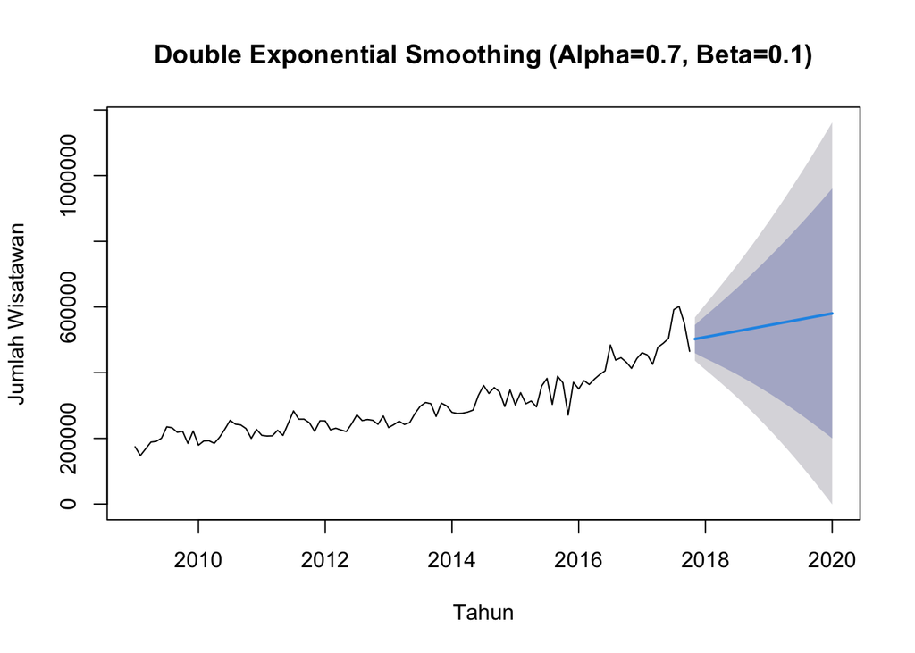

```r
plot(ramal_des1, xlab="Tahun", ylab="Jumlah Wisatawan",main="Double Exponential Smoothing (Alpha=0.7, Beta=0.1)")
```

#### Gabungan Data Aktual, Pemulusan, dan Ramalan

```r
data.des1 <- cbind(aktual=c(training.ts, rep(NA,26)),
                   pemulusan=c(NA, df_des1$fitted[,2], as.numeric(df_des1$coefficients[1]+df_des1$coefficients[2]), rep(NA,26)),
                   ramalan = c(NA, NA, df_des1$fitted[,1], df_ramal_des1$Point.Forecast))
data.des1 <- ts(data.des1, start=2013, freq=12)
data.des1
```

```
##          aktual pemulusan  ramalan
## Jan 2013 174541        NA       NA
## Feb 2013 147704  147704.0       NA
## Mar 2013 168205  154003.6 120867.0
## Apr 2013 188776  171287.3 130480.3
## May 2013 190803  179115.5 151844.6
## Jun 2013 200566  189116.2 162399.9
## Jul 2013 235198  217160.3 175072.3
## Aug 2013 232255  224776.0 207325.1
## Sep 2013 218443  217915.9 216686.0
## Oct 2013 221282  217882.1 209948.9
## Nov 2013 184803  192574.6 210708.3
## Dec 2013 222546  210858.4 183587.5
## Jan 2014 179273  186870.6 204598.4
## Feb 2014 191926  187999.6 178837.8
## Mar 2014 192579  189070.2 180882.9
## Apr 2014 184907  184266.6 182772.3
## May 2014 203388  195807.0 178118.1
## Jun 2014 228045  217059.7 191427.5
## Jul 2014 254907  243007.9 215243.4
## Aug 2014 243154  243398.2 243968.0
## Sep 2014 240947  241953.3 244301.3
## Oct 2014 229904  233719.3 242621.6
## Nov 2014 199861  209951.9 233497.4
## Dec 2014 227251  221288.3 207375.5
## Jan 2015 209093  212396.1 220103.2
## Feb 2015 207195  208168.6 210440.2
## Mar 2015 207907  207330.6 205985.5
## Apr 2015 224704  218877.4 205282.0
## May 2015 209058  211797.1 218188.4
## Jun 2015 245652  235097.1 210469.0
## Jul 2015 283524  269336.3 236231.8
## Aug 2015 258377  262998.3 273781.5
## Sep 2015 258440  260817.6 266365.2
## Oct 2015 247565  252384.4 263629.6
## Nov 2015 221603  231343.7 254071.9
## Dec 2015 253591  246741.2 230758.4
## Jan 2016 253286  251626.5 247754.2
## Feb 2016 225993  234103.1 253026.7
## Mar 2016 230957  231753.2 233611.0
```

[output cut: 79 more lines]

```
## Nov 2022     NA        NA 538417.5
## Dec 2022     NA        NA 541415.9
## Jan 2023     NA        NA 544414.4
## Feb 2023     NA        NA 547412.8
## Mar 2023     NA        NA 550411.2
## Apr 2023     NA        NA 553409.6
## May 2023     NA        NA 556408.0
## Jun 2023     NA        NA 559406.4
## Jul 2023     NA        NA 562404.8
## Aug 2023     NA        NA 565403.2
## Sep 2023     NA        NA 568401.7
## Oct 2023     NA        NA 571400.1
## Nov 2023     NA        NA 574398.5
## Dec 2023     NA        NA 577396.9
## Jan 2024 174541        NA 580395.3
```

#### Plot Hasil Pemulusan DES

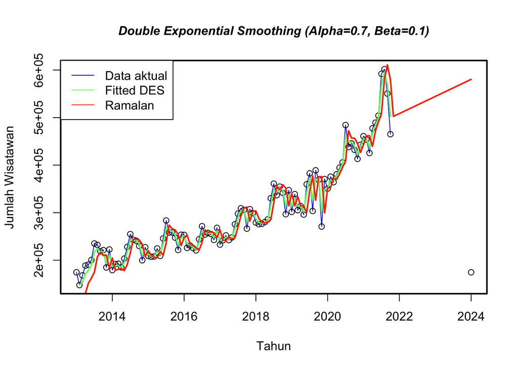

```r
ts.plot(data.des1[,1], xlab="Tahun", ylab="Jumlah Wisatawan", col="blue", lty=1)
points(data.des1[,1],col="black")
lines(data.des1[,2], col="#66FF66",lwd=2) #nilai dugaan
lines(data.des1[,3], col="#FF3300",lwd=2) #nilai dugaan
title("Double Exponential Smoothing (Alpha=0.7, Beta=0.1)",cex.main=1, font.main=4, col.main="black")
box(col="black",lwd=2)
legend("topleft", c("Data aktual", "Fitted DES","Ramalan"), lty=1,col=c ("blue","#66FF66","#FF3300"))
```

Berdasarkan eksplorasi di atas, plot data training hasil pemulusan menggunakan metode pemulusan DES dengan α = 0.7 dan β = 0.1 memiliki pola hampir sama dengan plot data aktual serta dibandingkan pula dengan data peramalannya.

#### Akurasi data testing DES

```r
selisihdes<-ramal_des1$mean-testing.ts
SSEtestingdes<-sum(selisihdes^2)
MSEtestingdes<-mean(selisihdes^2)
RMSEtestingdes<-sqrt(mean(selisihdes^2))
MADtestingdes<-mean(abs(selisihdes^2))
r.error.des <- (selisihdes/testing.ts)*100
      MAPEtestingdes <- mean(abs(r.error.des), na.rm = T)
akDES <- data.frame(SSE=SSEtestingdes,MSE=MSEtestingdes,RMSE=RMSEtestingdes,
                       MAD=MADtestingdes, MAPE=MAPEtestingdes)
akDES
```

```
##           SSE        MSE     RMSE        MAD    MAPE
## 1 48530379572 2854728210 53429.66 2854728210 9.29257
```

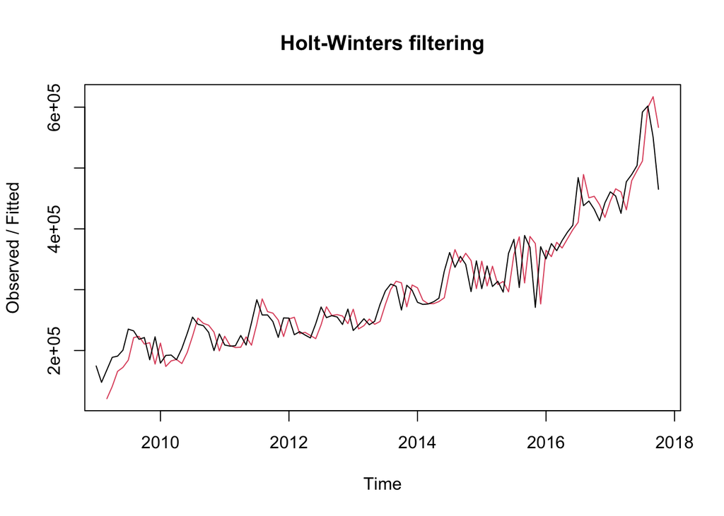

```r
#Lamda=0.9 dan gamma=0.1
des.1<- HoltWinters(training.ts, gamma = FALSE, beta = 0.1, alpha = 0.9)
plot(des.1)
```

```r
#ramalan
ramalandes1<- forecast(des.1, h=10)
ramalandes1
```

```
##          Point Forecast    Lo 80    Hi 80    Lo 95    Hi 95
## Nov 2017       475691.3 431817.6 519564.9 408592.2 542790.3
## Dec 2017       476128.1 414390.7 537865.4 381709.0 570547.1
## Jan 2018       476564.9 398740.1 554389.7 357542.1 595587.6
## Feb 2018       477001.7 383772.4 570230.9 334419.8 619583.5
## Mar 2018       477438.5 369051.8 585825.1 311675.4 643201.6
## Apr 2018       477875.3 354360.9 601389.6 288976.3 666774.2
## May 2018       478312.1 339577.5 617046.6 266135.9 690488.2
## Jun 2018       478748.9 324627.9 632869.8 243041.2 714456.5
## Jul 2018       479185.7 309465.4 648906.0 219620.9 738750.5
## Aug 2018       479622.5 294059.6 665185.4 195828.5 763416.4
```

```r
df_des1$fitted
```

```
##              xhat    level        trend
## Mar 2009 120867.0 147704.0 -26837.00000
## Apr 2009 130480.3 154003.6 -23523.34000
## May 2009 151844.6 171287.3 -19442.63820
## Jun 2009 162399.9 179115.5 -16715.55299
## Jul 2009 175072.3 189116.2 -14043.92871
## Aug 2009 207325.1 217160.3  -9835.12642
## Sep 2009 216686.0 224776.0  -8090.03688
## Oct 2009 209948.9 217915.9  -7967.04744
## Nov 2009 210708.3 217882.1  -7173.72729
## Dec 2009 183587.5 192574.6  -8987.10033
## Jan 2010 204598.4 210858.4  -6260.00522
## Feb 2010 178837.8 186870.6  -8032.78632
## Mar 2010 180882.9 187999.6  -7116.61561
## Apr 2010 182772.3 189070.2  -6297.89130
## May 2010 178118.1 184266.6  -6148.46162
## Jun 2010 191427.5 195807.0  -4379.57040
## Jul 2010 215243.4 217059.7  -1816.34311
## Aug 2010 243968.0 243007.9    960.10910
## Sep 2010 244301.3 243398.2    903.12712
## Oct 2010 242621.6 241953.3    668.32363
## Nov 2010 233497.4 233719.3   -221.91007
## Dec 2010 207375.5 209951.9  -2576.45648
## Jan 2011 220103.2 221288.3  -1185.16844
## Feb 2011 210440.2 212396.1  -1955.88024
## Mar 2011 205985.5 208168.6  -2183.04217
## Apr 2011 205282.0 207330.6  -2048.53779
## May 2011 218188.4 218877.4   -688.99883
## Jun 2011 210469.0 211797.1  -1328.12723
## Jul 2011 236231.8 235097.1   1134.68316
## Aug 2011 273781.5 269336.3   4445.13845
## Sep 2011 266365.2 262998.3   3366.82535
## Oct 2011 263629.6 260817.6   2812.06365
## Nov 2011 254071.9 252384.4   1687.54068
## Dec 2011 230758.4 231343.7   -585.28406
## Jan 2012 247754.2 246741.2   1012.99840
## Feb 2012 253026.7 251626.5   1400.22325
## Mar 2012 233611.0 234103.1   -492.13492
## Apr 2012 231075.3 231753.2   -677.91293
## May 2012 226095.2 227164.2  -1069.02242
```

[output cut: 50 more lines]

```
## Aug 2016 472352.3 461455.1  10897.21522
## Sep 2016 456902.2 448400.2   8502.00532
## Oct 2016 456790.8 449071.9   7718.97198
## Nov 2016 445586.4 439587.7   5998.66394
## Dec 2016 426672.2 422938.3   3733.85505
## Jan 2017 442824.5 437961.7   4862.80253
## Feb 2017 461546.9 455424.1   6122.77059
## Mar 2017 461847.0 456253.6   5593.43707
## Apr 2017 439452.5 436403.4   3049.07642
## May 2017 471770.4 466060.5   5709.88288
## Jun 2017 491036.6 484094.3   6942.27301
## Jul 2017 508069.3 500209.7   7859.58094
## Aug 2017 580590.9 566853.0  13737.95265
## Sep 2017 610724.5 595496.1  15228.46748
## Oct 2017 579595.5 568581.4  11014.14921
```

#### Membandingkan plot data latih dan data uji adalah sebagai berikut.

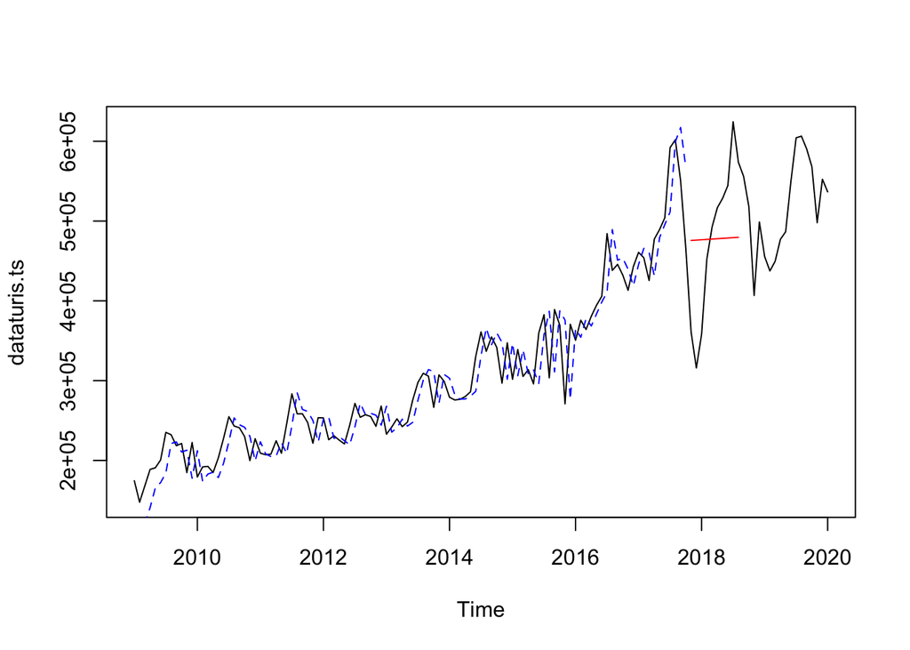

```r
#Visually evaluate the prediction
plot(dataturis.ts)
lines(des.1$fitted[,1], lty=2, col="blue")
lines(ramalandes1$mean, col="red")
```

#### Akurasi Data Training

```r
sse1 <- df_des1$SSE
mse1 <- sse1/length(training.ts)
rmse1 <-sqrt(mse1)
akurasi1 <- c("SSE"=sse1, "MSE"=mse1, "RMSE"=rmse1)
akurasi1
```

```
##          SSE          MSE         RMSE
## 1.173259e+11 1.106848e+09 3.326933e+04
```

#### Fungsi Mencari Parameter Optimum

```r
n = 10
df_acc_dma <- data.frame()

for(p in 2:n){
  mulussma <- TTR::SMA(training.ts, n=p)
  ts_dma <- TTR::SMA(mulussma, n=p)
  At <- 2*mulussma - ts_dma
  Bt <- 2/(2-1)*mulussma - ts_dma
  mulusdma <- At+Bt
  ramal_dma <- c(NA, mulusdma)
  df_dma <- cbind(Aktual=c(training.ts,NA), pemulusan=c(mulusdma,NA),
                  ramal_dma)
  head(df_dma)
  tail(df_dma)

  error.dma <- df_dma[,1]-df_dma[,3]
  SSE.dma <- sum(error.dma^2, na.rm=T)
  MSE.dma <- mean(error.dma^2, na.rm = T)
  RMSE.dma <- sqrt(mean(error.dma^2, na.rm = T))
  MAD.dma <- mean(abs(error.dma), na.rm = T)

  r.error.dma <- (error.dma/df_dma[,1])*100
  MAPE.dma <- mean(abs(r.error.dma), na.rm = T)

  vektor <- c(p, SSE.dma,MSE.dma,MAPE.dma,RMSE.dma,MAD.dma)
  df_acc_dma <- rbind(df_acc_dma, vektor)
}
colnames(df_acc_dma) <- c("n", "SSE","MSE","MAPE", "RMSE","MAD")
kableExtra::kable(df_acc_dma, align = rep('c',7), caption = "Perbandingan Error Pemulusan Metode DMA")
```

Perbandingan Error Pemulusan Metode DMA

| n | SSE | MSE | MAPE | RMSE | MAD |
| --- | --- | --- | --- | --- | --- |
| 2 | 1.028957e+13 | 99898724344 | 99.09808 | 316067.6 | 297681.5 |
| 3 | 1.021844e+13 | 101172683118 | 99.41451 | 318076.5 | 300618.5 |
| 4 | 1.010410e+13 | 102061656265 | 99.84589 | 319470.9 | 302408.9 |
| 5 | 9.912468e+12 | 102190395767 | 99.86932 | 319672.3 | 303229.6 |
| 6 | 9.686222e+12 | 101960232154 | 99.27379 | 319312.1 | 303371.5 |
| 7 | 9.468485e+12 | 101811669541 | 98.74784 | 319079.4 | 303780.3 |
| 8 | 9.301060e+12 | 102209452349 | 98.28871 | 319702.1 | 304708.2 |
| 9 | 9.139773e+12 | 102694077915 | 97.93424 | 320459.2 | 306272.9 |
| 10 | 9.010510e+12 | 103569078929 | 98.42564 | 321821.5 | 309003.1 |

Diperoleh nilai parameter yang optimal yaitu n=2

#### Forecasting menggunakan DMA

```r
 mulussma <- TTR::SMA(training.ts, n=2)
  ts_dma <- TTR::SMA(mulussma, n=2)
  At <- 2*mulussma - ts_dma
  Bt <- 2/(2-1)*(mulussma-ts_dma)
  mulusdma <- At+Bt
  ramal_dma <- c(NA, mulusdma)
  df_dma
```

```
##        Aktual pemulusan ramal_dma
##   [1,] 174541        NA        NA
##   [2,] 147704        NA        NA
##   [3,] 168205        NA        NA
##   [4,] 188776        NA        NA
##   [5,] 190803        NA        NA
##   [6,] 200566        NA        NA
##   [7,] 235198        NA        NA
##   [8,] 232255        NA        NA
##   [9,] 218443        NA        NA
##  [10,] 221282        NA        NA
##  [11,] 184803        NA        NA
##  [12,] 222546        NA        NA
##  [13,] 179273        NA        NA
##  [14,] 191926        NA        NA
```

[output cut: 93 more lines]

#### Plot DMA

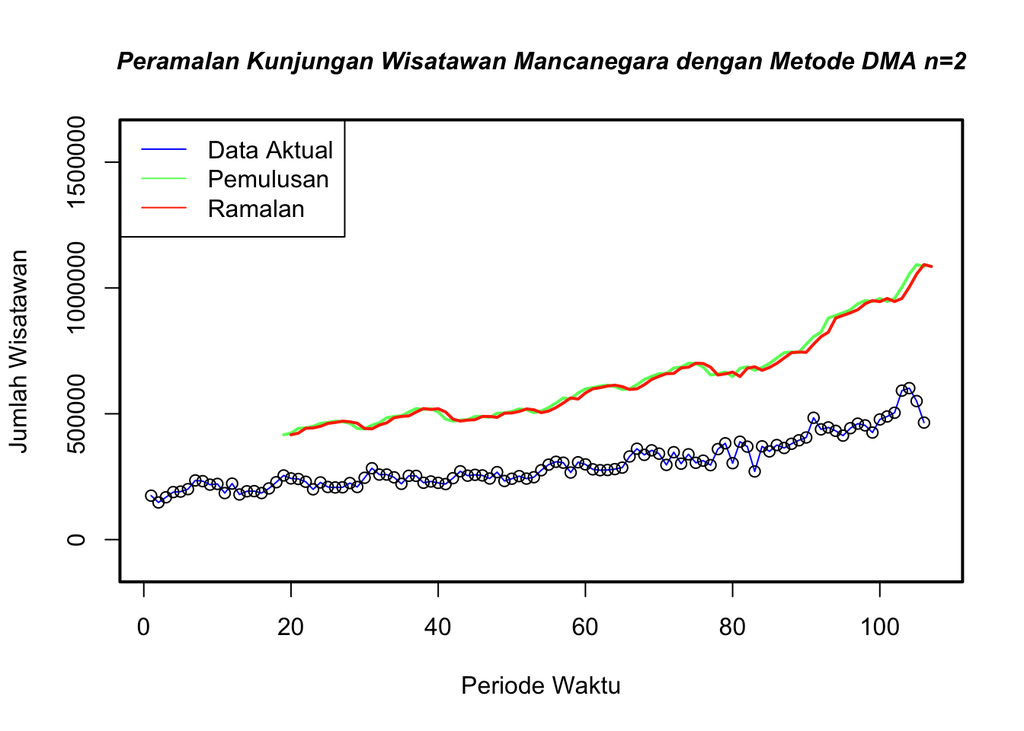

```r
# DMA Plot
ts.plot(df_dma[,1], xlab="Periode Waktu", ylab="Jumlah Wisatawan", col="blue", lty=1, ylim=c(-100000, 1600000))
points(df_dma[,1],col="black")
lines(df_dma[,2],col="#66FF66",lwd=2,lty=1)
lines(df_dma[,3],col="#FF3300",lwd= 2,lty=1)
title("Peramalan Kunjungan Wisatawan Mancanegara dengan Metode DMA n=2", cex.main=1, font.main=4 ,col.main="black")
legend("topleft", c("Data Aktual","Pemulusan","Ramalan"),lty=1,col=c ("blue","#66FF66","#FF3300"))
box(col="black",lwd=2)
```

#### Akurasi data Testing DMA

```r
      df.master <- data.frame()
      df_ts_sma <- TTR::SMA(testing.ts,  n=2)
      df_ts_dma <- TTR::SMA(df_ts_sma, n=2)
      At <- 2*df_ts_sma-df_ts_dma
      Bt <- 2/(2-1)*(df_ts_sma-df_ts_dma)
      pemulusan_dma <- At+Bt
      ramal_dma <- c(NA, pemulusan_dma)
      df_dma <- cbind(df_aktual=c(testing.ts,NA), pemulusan_dma=c(pemulusan_dma,NA), ramal_dma)
      error.dma <- df_dma[, 1] - df_dma[, 3]
      SSE.dma <- sum(error.dma^2, na.rm = T)
      MSE.dma <- mean(error.dma^2, na.rm = T)
      RMSE.dma <- sqrt(mean(error.dma^2, na.rm = T))
      MAD.dma <- mean(abs(error.dma), na.rm = T)
      r.error.dma <- (error.dma/df_dma[, 1])*100
      MAPE.dma <- mean(abs(r.error.dma), na.rm = T)
      ak <- data.frame(n=2,SSE=SSE.dma,MSE=MSE.dma,RMSE=RMSE.dma,
                       MAD=MAD.dma,MAPE=MAPE.dma)
      df.master <- rbind(df.master,ak)
      df.master
```

```
##   n         SSE        MSE     RMSE      MAD     MAPE
## 1 2 94266391501 3927766313 62671.89 51423.32 10.10657
```

### Winter’s Aditif

```r
aditif <- HoltWinters(training.ts, seasonal = "additive")
aditif
```

```
## Holt-Winters exponential smoothing with trend and additive seasonal component.
##
## Call:
## HoltWinters(x = training.ts, seasonal = "additive")
##
## Smoothing parameters:
##  alpha: 0.2450349
##  beta : 0.08035211
##  gamma: 0.2167068
##
## Coefficients:
##           [,1]
## a   524397.792
## b     6886.161
## s1  -22727.666
## s2   15935.542
## s3   -9461.378
## s4   -6582.688
## s5  -20294.165
## s6  -12871.726
## s7  -11592.663
## s8   13112.865
## s9   53386.535
## s10  27136.868
## s11  23469.999
## s12  -3810.467
```

#### Forecasting

```r
ramalan1 <- forecast(aditif, h=26)
ramalan1
```

```
##          Point Forecast    Lo 80    Hi 80    Lo 95    Hi 95
## Nov 2017       508556.3 478571.2 538541.4 462698.0 554414.5
## Dec 2017       554105.7 523087.7 585123.6 506667.8 601543.5
## Jan 2018       535594.9 503425.9 567763.9 486396.7 584793.1
## Feb 2018       545359.7 511923.4 578796.1 494223.2 596496.3
## Mar 2018       538534.4 503717.0 573351.9 485285.7 591783.1
## Apr 2018       552843.0 516534.2 589151.8 497313.5 608372.6
## May 2018       561008.3 523101.6 598914.9 503035.0 618981.5
## Jun 2018       592599.9 552993.0 632206.8 532026.4 653173.5
## Jul 2018       639759.8 598354.4 681165.1 576435.8 703083.8
## Aug 2018       620396.3 577098.5 663694.0 554178.0 686614.5
## Sep 2018       623615.6 578335.4 668895.7 554365.6 692865.6
## Oct 2018       603221.3 555872.8 650569.7 530808.0 675634.5
## Nov 2018       591190.2 540045.1 642335.4 512970.5 669410.0
## Dec 2018       636739.6 583433.9 690045.3 555215.6 718263.6
## Jan 2019       618228.8 562683.8 673773.9 533280.0 703177.6
## Feb 2019       627993.7 570133.6 685853.8 539504.3 716483.1
## Mar 2019       621168.4 560920.4 681416.3 529027.1 713309.6
## Apr 2019       635477.0 572771.2 698182.7 539576.8 731377.1
## May 2019       643642.2 578411.2 708873.2 543880.0 743404.4
## Jun 2019       675233.9 607412.6 743055.2 571510.2 778957.6
## Jul 2019       722393.7 651919.3 792868.1 614612.4 830175.0
## Aug 2019       703030.2 629842.0 776218.4 591098.5 814961.9
## Sep 2019       706249.5 630288.6 782210.4 590077.3 822421.7
## Oct 2019       685855.2 607064.6 764645.8 565355.3 806355.0
## Nov 2019       673824.1 590721.2 756927.1 546729.2 800919.1
## Dec 2019       719373.5 633380.4 805366.6 587858.5 850888.6
```

#### Akurasi data training

```r
sse1.train <- aditif$SSE
sse1.train
```

```
## [1] 51742287018
```

#### Plot Pemulusan

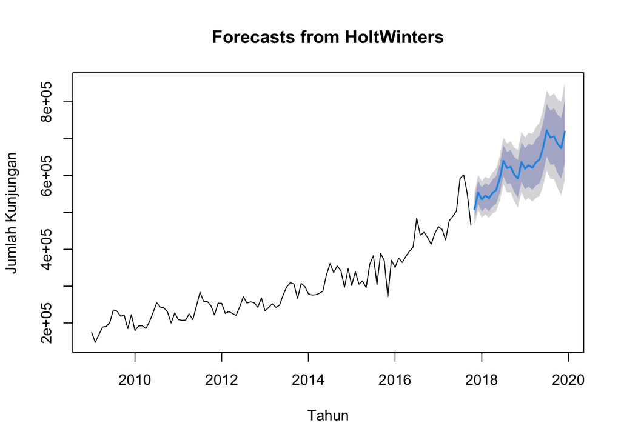

```r
plot(ramalan1, xlab="Tahun", ylab="Jumlah Kunjungan")
```

### Winter’s Multiplikatif

#### Pemulusan

```r
multi <- HoltWinters(training.ts, seasonal = "multiplicative")
multi
```

```
## Holt-Winters exponential smoothing with trend and multiplicative seasonal component.
##
## Call:
## HoltWinters(x = training.ts, seasonal = "multiplicative")
##
## Smoothing parameters:
##  alpha: 0.180047
##  beta : 0.0831555
##  gamma: 0.3319109
##
## Coefficients:
##             [,1]
## a   5.156490e+05
## b   6.616313e+03
## s1  9.273622e-01
## s2  1.056141e+00
## s3  9.848611e-01
## s4  9.929916e-01
## s5  9.420011e-01
## s6  9.690901e-01
## s7  9.638264e-01
## s8  1.034718e+00
## s9  1.164237e+00
## s10 1.081881e+00
## s11 1.083410e+00
## s12 9.965894e-01
```

#### Forecasting

```r
ramalan2 <- holt(training.ts, damped = TRUE, seasonal = "multiplicative", h=14)
ramalan2
```

```
##          Point Forecast    Lo 80    Hi 80    Lo 95    Hi 95
## Nov 2017       507537.2 467310.4 547764.1 446015.6 569058.9
## Dec 2017       508496.6 461908.0 555085.3 437245.5 579747.8
## Jan 2018       509436.9 457254.7 561619.0 429631.1 589242.6
## Feb 2018       510358.3 453125.1 567591.5 422827.7 597888.9
## Mar 2018       511261.3 449386.6 573135.9 416632.2 605890.4
## Apr 2018       512146.2 445953.5 578338.9 410913.2 613379.2
## May 2018       513013.4 442766.4 583260.5 405579.9 620447.0
## Jun 2018       513863.3 439782.4 587944.3 400566.3 627160.3
## Jul 2018       514696.2 436969.3 592423.2 395823.1 633569.4
## Aug 2018       515512.5 434302.0 596722.9 391311.8 639713.1
## Sep 2018       516312.4 431760.9 600863.8 387002.1 645622.6
## Oct 2018       517096.3 429330.1 604862.5 382869.4 651323.1
## Nov 2018       517864.5 426996.4 608732.6 378893.7 656835.3
## Dec 2018       518617.4 424749.0 612485.7 375058.1 662176.7
```

#### Akurasi data training

```r
sse2.train <- multi$SSE
sse2.train
```

```
## [1] 56502455606
```

#### Plot Pemulusan

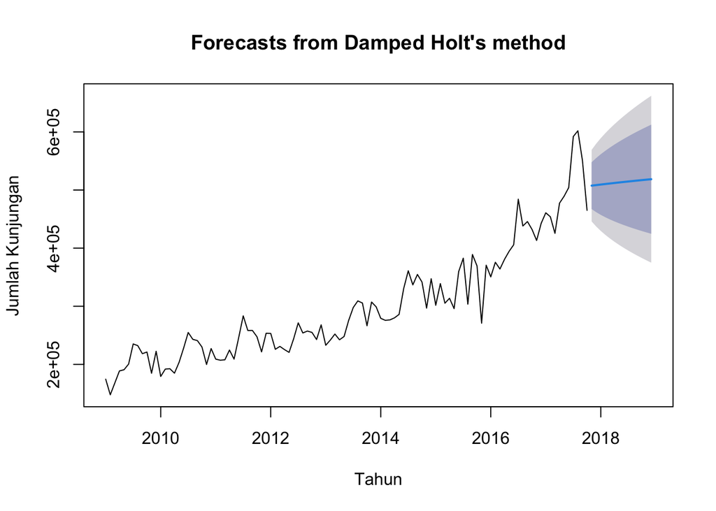

```r
plot(ramalan2, xlab="Tahun", ylab="Jumlah Kunjungan")
```

```r
selisih1<-as.numeric(ramalan1$mean)-as.numeric(testing.ts)
```

```r
SSEtesting1<-sum(selisih1^2)
MSEtesting1<-mean(selisih1^2)
RMSEtesting1<-sqrt(mean(selisih1^2))
MADtesting1<-mean(abs(selisih1^2))
r.error.testing1 <- (selisih1/testing.ts)*100
      MAPEtesting1 <- mean(abs(r.error.testing1), na.rm = T)

selisih2<-as.numeric(ramalan2$mean)-as.numeric(testing.ts)
SSEtesting2<-sum(selisih2^2)
MSEtesting2<-mean(selisih2^2)
RMSEtesting2<-sqrt(mean(selisih2^2))
MADtesting2<-mean(abs(selisih2^2))
r.error.testing2 <- (selisih1/testing.ts)*100
      MAPEtesting2 <- mean(abs(r.error.testing2), na.rm = T)


akurasi <- matrix(c(SSEtesting1, MSEtesting1, RMSEtesting1, MADtesting1, MAPEtesting1, SSEtesting2,  MSEtesting2,  RMSEtesting2, MADtesting2, MAPEtesting2), nrow=5, ncol=2)
row.names(akurasi)<- c("SSE", "MSE", "RMSE", "MAD", "MAPE")
colnames(akurasi) <- c("Aditif", "Multiplikatif")
akurasi
```

```
##            Aditif Multiplikatif
## SSE  4.607289e+11  1.578783e+11
## MSE  1.706403e+10  5.847343e+09
## RMSE 1.306294e+05  7.646792e+04
## MAD  1.706403e+10  5.847343e+09
## MAPE 2.527120e+01  2.527120e+01
```

### Perbandingan Nilai Akurasi Semua Metode

```r
akurasi <- matrix(c(SSE.dma, MSE.dma, MAD.dma, MAPE.dma, SSEtestingdes,  MSEtestingdes,  MADtestingdes, MAPEtestingdes, SSEtesting1, MSEtesting1, MADtesting1, MAPEtesting1, SSEtesting2,  MSEtesting2, MADtesting2, MAPEtesting2), nrow=4)
row.names(akurasi)<- c("SSE", "MSE", "MAD", "MAPE")
colnames(akurasi) <- c("DMA", "DES", "Winter Aditif", "Winter Multiplikatif")
kableExtra::kable(akurasi,caption = 'Penentuan Model Smoothing Terbaik',  align = rep('c',7))
```

Penentuan Model Smoothing Terbaik

|  | DMA | DES | Winter Aditif | Winter Multiplikatif |
| --- | --- | --- | --- | --- |
| SSE | 9.426639e+10 | 4.853038e+10 | 4.607289e+11 | 1.578783e+11 |
| MSE | 3.927766e+09 | 2.854728e+09 | 1.706403e+10 | 5.847343e+09 |
| MAD | 5.142332e+04 | 2.854728e+09 | 1.706403e+10 | 5.847343e+09 |
| MAPE | 1.010657e+01 | 9.292570e+00 | 2.527120e+01 | 2.527120e+01 |